# Redes en Biología

## UNAM: Dia 2 / GRAFO CLUB DE KARATE

INTERES:

- Distribución de grados
- Número Componentes Conexas

PREGUNTA: **¿Qué es una componente conexa?**

- Es el número de subgrafos identificados dentro del grafo que no estén conectados.

```python
#COMPONENTES CONEXAS
nx.number_connected_components(kG)
```

```
1
```

```python
#DIAMETRO
nx.diameter(kG)
```

```
5
```

```python
#EXENTRICIDAD
nx.eccentricity(kG)
```

```
{0: 3,
 1: 3,
 2: 3,
 3: 3,
 4: 4,
 5: 4,
 6: 4,
 7: 4,
 8: 3,
 9: 4,
 10: 4,
 11: 4,
 12: 4,
 13: 3,
 14: 5,
```

[output cut: 19 more lines]

```python
#INICIO DISTRIBUCION DE GRADOS
#crear un DICCIONARIO con estructura { D.keys(): D.values() }
D= kG.degree(kG)
type(D)
```

```
dict
```

```python
D
```

```
{0: 16,
 1: 9,
 2: 10,
 3: 6,
 4: 3,
 5: 4,
 6: 4,
 7: 4,
 8: 5,
 9: 2,
 10: 3,
 11: 1,
 12: 2,
 13: 5,
 14: 2,
```

[output cut: 19 more lines]

```python
#LISTA con [llaves] o ELEMENTOS VERTICES
#D.keys()
```

```python
#LISTA con valores de GRADO para cada ELEMENTO VERTICE
#D.values()
```

```python
#al igual que el DICCIONARIO con estructura { D.keys(): D.values() }
#la LISTA posee la estructura con estructura ( D.keys()[i], D.values()[i] )
#LISTA de TUPLAS usado luego para ordernar ELEMENTOS VERTICES de acuerdo a su respectivo GRADO
type(D.items())
```

```
list
```

```python
type(D.items()[1])
```

```
tuple
```

```python
D.items()[1]
```

```
(1, 9)
```

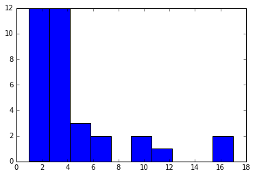

```python
#DISTRIBUCION DE GRADOS por HISTOGRAMA
plt.hist(D.values())
```

```python
#DISTRIBUCION DE GRADOS por histograma NORMALIZADO
#plt.hist(D.values(), normed=True)
```

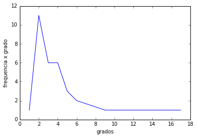

```python
#DISTRIBUCION DE GRADOS por PLOTEO
kG_grados = nx.degree(kG)
kGg = sorted(set(kG_grados.values()))
kG_freq= [kG_grados.values().count(g) for g in kGg]
plt.plot(kGg, kG_freq)
plt.xlabel('grados')
plt.ylabel('frequencia x grado')
```

Graficar una **LISTA** ordenada. LISTA con valores de GRADO para cada ELEMENTO VERTICE

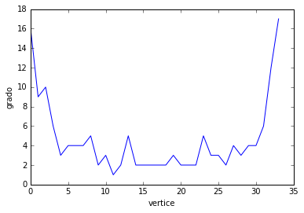

```python
#VISUALIZACION DE { eje X: elementos VERTICE x eje Y: GRADO de cada vertice }
#plt.plot(sorted(D.values(), reverse=True))
plt.plot(D.values())
plt.xlabel('vertice')
plt.ylabel('grado')
```

```python
#plt.plot(sorted(D.values(), reverse=True), 'o')
#plt.xlabel('vertices ordenados')
#plt.ylabel('grado')
```

```python
#TUPLAS de VERTICES x ARISTAS , como D pero en TUPLAS
#D.items()
```

```python
#ADD an ADJACENT MATRIX from NUMMPY
#nx.from_numpy_matrix
```

## UNAM: Día 2 / RED DE INTERACCIÓN GÉNICA

### READ .txt reguloDB

```python
ls
```

```
blueKarate.jpg     redKarate.jpg  scriptUNAM.py    UNAM_mat2.py
FIRSTpynb_1.ipynb  regulonDB.txt  UNAM_mat2.html
READregulon.py     script.py      UNAM_mat2.ipynb
```

```python
#run READregulon.py

#EVITAR ESPACIOS EN BLANCO AL FINAL DEL TEXTO!!!

#leyendo la info del grafo
regulon= 'regulonDB.txt'
f= open(regulon, 'r')
regLines= f.readlines()
f.close()
```

```python
len(regLines)
```

```
4459
```

```python
regLines[224]
```

```
'ArcA\tnuoB\t-\t[BCE, GEA, SM]\tWeak\t\n'
```

```python
regLines[0]
```

```
'# Copies and Copyright-Notice\n'
```

```python
regLines[224][0] != '#'
```

```
True
```

```python
regLines[0][0] != '#'
```

```
False
```

```python
L= 'una Linea DE textO con MAYUSCULAS y minUSCULAS'
L.lower().split()
```

```
['una', 'linea', 'de', 'texto', 'con', 'mayusculas', 'y', 'minusculas']
```

```python
#construyendo el grafo
redE = nx.DiGraph()

#construir un loop
for linea in regLines:
    if linea[0] != '#':
        info= linea.lower().split()
        redE.add_edge(info[0],info[1])
```

```python
info
```

```
['zur', 'znuc', '-', '[bpp,', 'gea,', 'hibscs]', 'strong']
```

```python
#regLines[2]
```

```python
redE
```

```
<networkx.classes.digraph.DiGraph at 0x7f3b3102c150>
```

```python
redE.order() #VERTICES NODES ELEMENTOS
```

```
1850
```

```python
redE.size() #ARISTAS EDGES CONEXIONES
```

```
4219
```

```python
redE.edges()[:4]
```

```
[('xapr', 'xapa'), ('xapr', 'xapb'), ('mata', 'tcyj'), ('mata', 'fliz')]
```

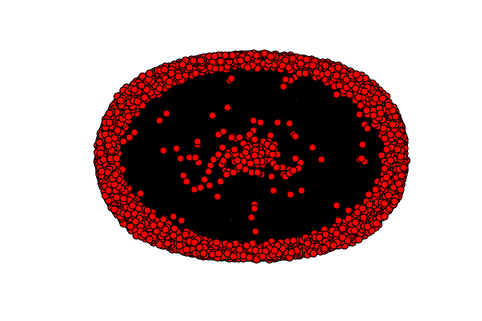

```python
nx.draw(redE, node_size=50)
```

```python
#pos= nx.circular_layout(redE)
#nx.draw(redE, node_size=50, pos)
```

```python
#nx.draw_spring(redE, with_labels = True, node_size = 500, node_color = 'b', alpha= .8)
```

### Descripción del grafo

```python
#COMPONENTES CONEXAS ---> NOT FOR DIRECTED GRAPH
#nx.number_connected_components(redE)
```

```python
#EXENTRICIDAD -----> NOT CONNECTED
#nx.eccentricity(redE)
```

```python
#DIAMETRO   -------> NOT CONNECTED
#nx.diameter(redE)
```

#### Transformar **Grafo Dirigido** a *Grafo NO Dirigido*

Realizamos esta transformación con el fin de encontrar las *componentes conexas* de la red génica de E.coli, la cual es un grafo dirigido.

```python
E= nx.Graph(redE)
E
```

```
<networkx.classes.graph.Graph at 0x7f3b30239550>
```

```python
#COMPONENTES CONEXAS ---> NOT FOR DIRECTED GRAPH
nx.number_connected_components(E)
```

```
24
```

¿cuántos **nodos** tienen cada una de las **24 componentes conexas**?

Determina número de **grafos conexos** con determinado número de nodos

```python
E_components = nx.connected_component_subgraphs(E)
E_components
```

```
<generator object connected_component_subgraphs at 0x7f3b307bec80>
```

```python
for g in E_components:
    print(g.order())
```

```
1749
3
5
5
2
13
9
4
5
3
4
2
2
6
1
3
3
4
2
7
4
6
5
3
```

En comparación con el de **GRAFO ALEATORIA DE BARABASI**, este último solo poseerá un grafo conexo, ya que cada nodo por definición estará unido a otro nodo por un solo vértice.

**AHORA**, graficamos los **GRAFOS CONEXOS**

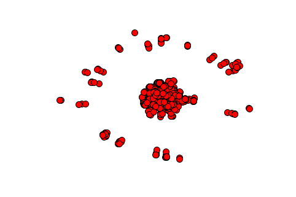

```python
nx.draw_spring(E, node_size=100)
```

**AHORA** visualizaremos tan solo los grados presentes en el **DICCIONARIO** $E grados$ que está compuesto por todos los $nodos$ y su respectivo número de $aristas$

```python
E_grados = nx.degree(E)
type(E_grados)
```

```
dict
```

```python
#primero extraigo los valores del diccionario,
#luego los reduzco a un conjunto con los elementos únicos -sin repeticiones- y
#finalmente los ordeno de menor a mayor
Eg = sorted(set(E_grados.values()))
len(Eg)
```

```
49
```

```python
Eg
```

```
[1,
 2,
 3,
 4,
 5,
 6,
 7,
 8,
 9,
 10,
 11,
 12,
 13,
 14,
 15,
 16,
 17,
 18,
 19,
 20,
 22,
 23,
 24,
 25,
 28,
 33,
 34,
 36,
 39,
 40,
 44,
 45,
 46,
 50,
 56,
 60,
 61,
 69,
 80,
 83,
 109,
 124,
 133,
 173,
 186,
 222,
 229,
 299,
 514]
```

**AHORA**, con el fin de OBTENER la FRECUENCIA de cada uno de los GRADOS obtenidos arriba, a partir de la LISTA de valores extraida del DICCIONARIO, la cual contiene todas las repeticiones de los GRADOS, **CONTAREMOS** cada una de sus repeticiones:

*-aquí será importante la LISTA DE COMPRENSIÓN-*

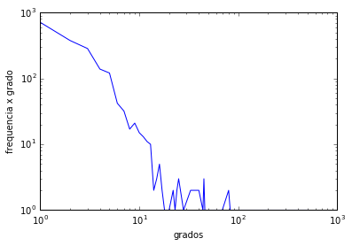

```python
E_freq= [E_grados.values().count(g) for g in Eg]
plt.loglog(Eg, E_freq)
plt.xlabel('grados')
plt.ylabel('frequencia x grado')
```

### Distribución de Grados

```python
#INICIO DISTRIBUCION DE GRADOS
#crear un DICCIONARIO: { D.keys() x D.values() }
DEc= redE.degree(redE)
#D
```

```python
#DEFINIR FUNCION para una t: tupla
def segundaComponente(t):
    return t[1]
```

```python
#TUPLAS ordenadas por "POPULARIDAD" nodos o vertices X aristas o conexiones
sorted(DEc.items(), key=segundaComponente)[-5:]
```

```
[('h-ns', 186), ('ihf', 222), ('fis', 230), ('fnr', 300), ('crp', 515)]
```

```python
#TUPLAS ordenadas por "POPULARIDAD" nodos o vertices X aristas o conexiones
sorted(DEc.items(), key=segundaComponente)[:5]
```

```
[('rplu', 1), ('hcha', 1), ('pgpc', 1), ('xapa', 1), ('xapb', 1)]
```

```python
#plt.hist?
```

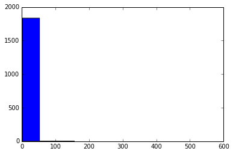

```python
#DISTRIBUCION DE GRADOS por histograma
plt.hist(DEc.values())
```

```python
#DISTRIBUCION DE GRADOS por histograma NORMALIZADO
#plt.hist(DEc.values(), normed=True)
```

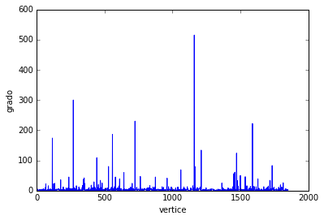

```python
#DISTRIBUCION DE GRADOS
#plt.plot(sorted(D.values(), reverse=True))
plt.plot(DEc.values())
plt.xlabel('vertice')
plt.ylabel('grado')
```

```python
DCEc=nx.degree_centrality(redE)
#plt.hist(DCEc.values())
```

```python
DBEc=nx.betweenness_centrality(redE)
#plt.hist(DBEc.values())
```

```python
nx.flow_hierarchy(redE)
```

```
0.9658686892628585
```

## UNAM: Día 2 / GENERATE A RANDOM GRAPH

Generamos un **GRAFO ALEATORIO** con nx.barabasi_albert_graph($n$,$m$) donde $n$ es el número de nodos en el grafo y $m$ es el número de aristas de un nuevo nodo

```python
#GRAFO ALEATORIO
B= nx.barabasi_albert_graph(redE.order(),min(DEc.values())) #VALUES extracted from Ecoli GRN: #VERTICES and min(#ARISTAS)=1
B
```

```
<networkx.classes.graph.Graph at 0x7f3b2eda6b10>
```

```python
#nx.barabasi_albert_graph?
```

```python
#NÚMERO DE VERTICES
B.order()
```

```
1850
```

```python
#NÚMERO DE ARISTAS
B.size()
```

```
1849
```

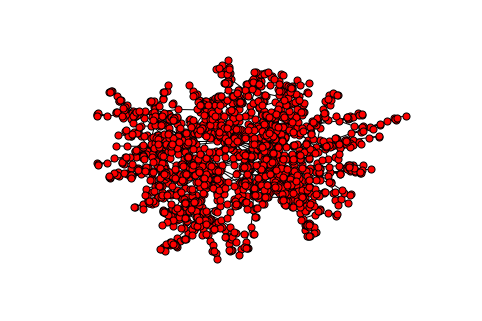

```python
nx.draw(B, node_size=50)
```

```python
#COMPONENTES CONEXAS ---> NOT FOR DIRECTED GRAPH
nx.number_connected_components(B)
```

```
1
```

A diferencia de la Red de regulación génica, la **red de Barabasi** tiene solo **1 componente conexo**

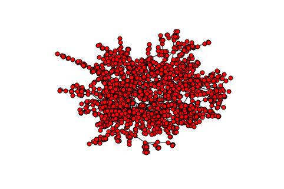

```python
nx.draw_spring(B, node_size=50)
```

```python
#DIAMETRO
nx.diameter(B)
```

```
21
```

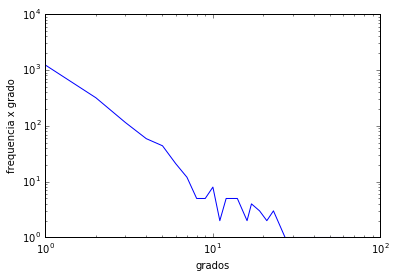

```python
#DISTRIBUCION DE GRADOS por PLOTEO
B_grados = nx.degree(B)
Bg = sorted(set(B_grados.values()))
B_freq= [B_grados.values().count(g) for g in Bg]
plt.loglog(Bg, B_freq)
plt.xlabel('grados')
plt.ylabel('frequencia x grado')
```

```python
#EXENTRICIDAD ----> ENTENDER / RESULTADO PROLONGADO
#nx.eccentricity(B)
```

```python
#INICIO DISTRIBUCION DE GRAFOS
#crear un DICCIONARIO: D.keys() x D.values()
DB= B.degree(B)
```

```python
#DEFINIR FUNCION para una t: tupla
def segundaComponente(t):
    return t[1]
```

```python
#TUPLAS ordenadas por "POPULARIDAD" nodos o vertices X aristas o conexiones
sorted(D.items(), key=segundaComponente)[-5:]
```

```
[(1, 9), (2, 10), (32, 12), (0, 16), (33, 17)]
```

```python
#TUPLAS ordenadas por "POPULARIDAD" nodos o vertices X aristas o conexiones
sorted(D.items(), key=segundaComponente)[:5]
```

```
[(11, 1), (9, 2), (12, 2), (14, 2), (15, 2)]
```

```python
#TUPLAS ordenadas por "POPULARIDAD" nodos o vertices X aristas o conexiones
sorted(DB.items(), key=segundaComponente)[-5:]
```

```
[(50, 23), (56, 27), (41, 30), (3, 49), (5, 66)]
```

```python
#TUPLAS ordenadas por "POPULARIDAD" nodos o vertices X aristas o conexiones
sorted(DB.items(), key=segundaComponente)[:5]
```

```
[(2, 1), (8, 1), (19, 1), (29, 1), (36, 1)]
```

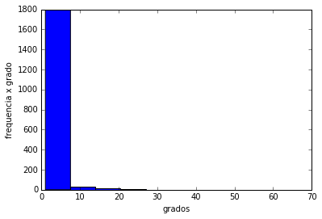

```python
#DISTRIBUCION DE GRADOS por histograma
plt.hist(DB.values())
plt.xlabel('grados')
plt.ylabel('frequencia x grado')
```

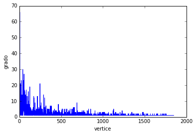

```python
#DISTRIBUCION DE GRADOS
#plt.plot(sorted(D.values(), reverse=True))
plt.plot(DB.values())
plt.xlabel('vertice')
plt.ylabel('grado')
```

```python
DCB=nx.degree_centrality(B)
#plt.hist(DCB.values())
```

```python
DBB= nx.betweenness_centrality(B)
#plt.hist(DBB.values())
```

```python
#nx.flow_hierarchy(B)
```

## COMPARISON GRAPHICS

```python
#?nx.draw_networkx
```

```python
B_degree = nx.degree(B)
np.mean(B_degree.values())
```

```
1.9989189189189189
```

```python
redE_degree = nx.degree(redE)
np.mean(redE_degree.values())
```

```
4.5610810810810811
```

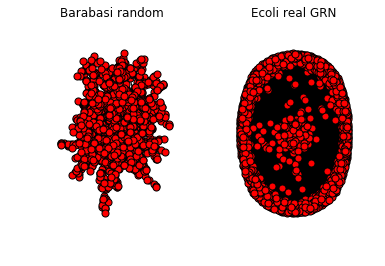

```python
plt.subplot(1,2,1)
nx.draw(B, node_size=50)
plt.title('Barabasi random')
plt.subplot(1,2,2)
nx.draw(redE, node_size=50)
plt.title('Ecoli real GRN')
plt.show()
```

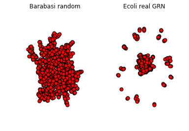

```python
plt.subplot(1,2,1)
nx.draw_spring(B, node_size=50)
plt.title('Barabasi random')
plt.subplot(1,2,2)
nx.draw_spring(E, node_size=50)
plt.title('Ecoli real GRN')
plt.show()
```

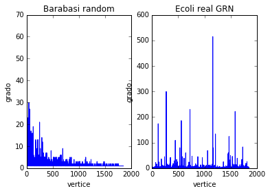

```python
plt.subplot(1,2,1)
plt.plot(DB.values())
plt.title('Barabasi random')
plt.xlabel('vertice')
plt.ylabel('grado')
plt.subplot(1,2,2)
plt.plot(DEc.values())
plt.title('Ecoli real GRN')
plt.xlabel('vertice')
plt.ylabel('grado')
plt.show()
```

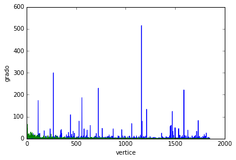

```python
#plt.subplot(1,2,1)
plt.plot(DEc.values())
plt.xlabel('vertice')
plt.ylabel('grado')
#plt.subplot(1,2,2)
plt.plot(DB.values())
#plt.xlabel('vertice')
#plt.ylabel('grado')
#plt.show()
```

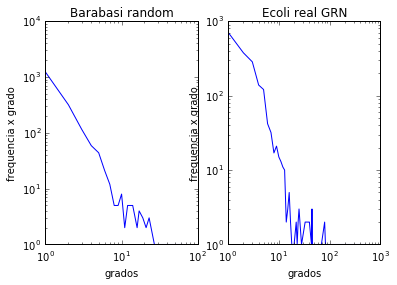

```python
plt.subplot(1,2,1)
plt.loglog(Bg, B_freq)
plt.title('Barabasi random')
plt.xlabel('grados')
plt.ylabel('frequencia x grado')
plt.subplot(1,2,2)
plt.loglog(Eg, E_freq)
plt.title('Ecoli real GRN')
plt.xlabel('grados')
plt.ylabel('frequencia x grado')
plt.show()
```

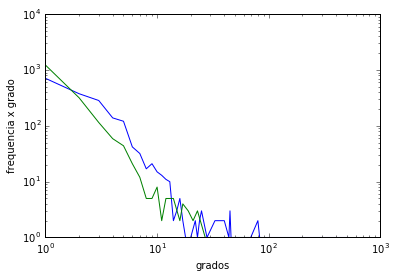

```python
#plt.subplot(1,2,1)
plt.loglog(Eg, E_freq)
plt.xlabel('grados')
plt.ylabel('frequencia x grado')
#plt.subplot(1,2,2)
plt.loglog(Bg, B_freq)
#plt.xlabel('grados')
#plt.ylabel('frequencia x grado')
plt.show()
```

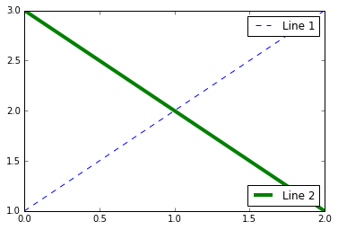

```python
line1, = plt.plot([1,2,3], label="Line 1", linestyle='--')
line2, = plt.plot([3,2,1], label="Line 2", linewidth=4)

# Create a legend for the first line.
first_legend = plt.legend(handles=[line1], loc=1)

# Add the legend manually to the current Axes.
ax = plt.gca().add_artist(first_legend)

# Create another legend for the second line.
plt.legend(handles=[line2], loc=4)

plt.show()
```